# Gsynth implementation

ME

## Initialize

```r
# rm(list=ls())
```

```r
# Main
library(gsynth)
library(panelView)

# Instrumental
library(dplyr)
library(leaflet)
library(tidyr)
library(ggplot2)
library(tmap)
```

## Load data and variables

```r
main_dta <- readRDS("data/main_dta.rds")
nuts_treated <- readRDS("data/nuts_sf_treated") %>%
  sf::st_as_sf()
```

## Clean dataset + Create relative outcomes

```r
# Create relative outcomes

main_dta <- main_dta %>%
  filter(time >= 2000) %>%
  group_by(geo) %>%
  mutate(gdp_eur_hab_perc =
           (100*gdp_eur_hab)/first(gdp_eur_hab,)) %>%
  ungroup()


# Create treatment variables
main_dta <- main_dta %>%
  mutate(
    is_inagurated = case_when(
      is.na(year_stage1) ~ 0, # If its control, never inagurated
      time < year_stage1 ~ 0, # If its before the inaguration
      TRUE ~ 1 # if neither, then its after
    ),
    # create a placebo treatment
    is_inagurated_3y = case_when(
      is.na(year_stage1) ~ 0, # If its control, never inagurated
      time < year_stage1 - 3 ~ 0, # If its more than 3 years beforethe inaguration
      TRUE ~ 1 # if neither, then its after
    ),
    is_announced = case_when(
      is.na(year_stage1) ~ as.integer(0), # If its control, never
      is.na(year_announced) ~ NA_integer_, # If i dont have date of announcment, forget observaton
      time < year_announced ~ as.integer(0), # If its before
      TRUE ~ as.integer(1) # if neither, then its after
    ),
    is_announced_2y = case_when(
      is.na(year_stage1) ~ as.integer(0), # If its control, never
      is.na(year_announced) ~ NA_integer_, # If i dont have date of announcment, forget observaton
      time < year_announced - 2 ~ as.integer(0), # If its before
      TRUE ~ as.integer(1) # if neither, then its after
    ),
    is_announced_3y = case_when(
      is.na(year_stage1) ~ as.integer(0), # If its control, never
      is.na(year_announced) ~ NA_integer_, # If i dont have date of announcment, forget observaton
      time < year_announced - 3 ~ as.integer(0), # If its before
      TRUE ~ as.integer(1) # if neither, then its after
    ),
    is_announced_4y = case_when(
      is.na(year_stage1) ~ as.integer(0), # If its control, never
      is.na(year_announced) ~ NA_integer_, # If i dont have date of announcment, forget observaton
      time < year_announced - 4 ~ as.integer(0), # If its before
      TRUE ~ as.integer(1) # if neither, then its after
    ),
    is_announced_6y = case_when(
      is.na(year_stage1) ~ as.integer(0), # If its control, never
      is.na(year_announced) ~ NA_integer_, # If i dont have date of announcment, forget observaton
      time < year_announced - 6 ~ as.integer(0), # If its before
      TRUE ~ as.integer(1) # if neither, then its after
    )
  )

# Review results
main_dta %>%
  select(geo, time, LEZ, gdp_eur_hab_perc,
         Stage_1, is_inagurated,
         Announcment, is_announced, is_announced_2y
         )  %>%
  filter(!is.na(Stage_1))
```

| geo | time | LEZ | gdp_eur_hab_perc | Stage_1 | is_inagurated | Announcment | is_announced | is_announced_2y |
| --- | --- | --- | --- | --- | --- | --- | --- | --- |
| DE13 | 2000 | Freiburg | 100.00000 | 01.01.2010 | 0 | 2006-03-01 | 0 | 0 |
| DE13 | 2001 | Freiburg | 102.34375 | 01.01.2010 | 0 | 2006-03-01 | 0 | 0 |
| DE13 | 2002 | Freiburg | 102.34375 | 01.01.2010 | 0 | 2006-03-01 | 0 | 0 |
| DE13 | 2003 | Freiburg | 102.34375 | 01.01.2010 | 0 | 2006-03-01 | 0 | 0 |
| DE13 | 2004 | Freiburg | 104.29688 | 01.01.2010 | 0 | 2006-03-01 | 0 | 1 |
| DE13 | 2005 | Freiburg | 105.46875 | 01.01.2010 | 0 | 2006-03-01 | 0 | 1 |
| DE13 | 2006 | Freiburg | 111.32812 | 01.01.2010 | 0 | 2006-03-01 | 1 | 1 |
| DE13 | 2007 | Freiburg | 116.40625 | 01.01.2010 | 0 | 2006-03-01 | 1 | 1 |
| DE13 | 2008 | Freiburg | 119.53125 | 01.01.2010 | 0 | 2006-03-01 | 1 | 1 |
| DE13 | 2009 | Freiburg | 112.10938 | 01.01.2010 | 0 | 2006-03-01 | 1 | 1 |

[output cut: 990 more lines]

> I need to include some for NUTS 3 too!

Delete some treated that are not clear enough to analyse:

```r
confusing_treated <- c(
  "DE714", # Weissbaden
  "DEB35" # Mainz
)

# NOTE: Weissbaden and MAIZ have the same implementation but different announcemnts. They share geography (MAIN's LEZ is inside Weissbaden NUTS3). I could delete Weissbaden and only keep Mainz given it was announced first. Both go directly to "GREEN" plakettes.

not_optimal_treated <- c(
  "DEA1F", # Dinslaken is in a LARGE NUTS3 that involves many cities that have NOT applied LEZ
  "DEA2B", # Overath has the same characterisitics, LARGE NUTS, small city and small LEZ
  "DE123", # Same for Pfinztal.
  "DE12B", # Same for Mühlacker
  "DE118", # Same for Ilsfeld
  "DE116", # Same for Urbach,
  "DE113", # Same for Wendlingen
  "DE11D", # Same for Schwäbisch Gmünd
  "DE135", # Same for Schramberg
  "DE279" # Same for Neu-Ulm
)

# Filter confunsig regions and NUTS 3 regions:
main_dta <- main_dta %>%
  filter(nuts_level == 3) %>%
  mutate(not_optimal = ifelse(geo %in% not_optimal_treated,
                              TRUE, FALSE),
         confusing_tr = ifelse(geo %in% confusing_treated,
                              TRUE, FALSE))

# Restrict sample to cities that applied a LEZ after the end of the srappage program
main_dta <- main_dta %>%
  # mutate(date_fake = as.Date("01-10-2019", "%d-%m-%Y")) %>%
  filter(treated_uz == FALSE |
           date_announced >= as.Date("01-10-2009", "%d-%m-%Y"))

# Look at treated regions:
main_dta %>%
  select(geo, LEZ, date_announced, Stage_1,
         not_optimal, urb_index)  %>%
  unique() %>%
  arrange(date_announced) %>%
  filter(!is.na(date_announced)) # select only the treated
```

| geo | LEZ | date_announced | Stage_1 | not_optimal | urb_index |
| --- | --- | --- | --- | --- | --- |
| DEA22 | Bonn | 2009-10-01 | 01.01.2010 | FALSE | 1.818182 |
| DEA1D | Neuss | 2009-12-01 | 15.02.2010 | FALSE | 1.750000 |
| DED51 | Leipzig | 2009-12-18 | 01.03.2011 | FALSE | 2.230769 |
| DEB35 | Mainz | 2010-03-27 | 01.02.2013 | FALSE | 1.857143 |
| DEA14 | Krefeld | 2010-10-01 | 01.01.2011 | FALSE | 1.625000 |
| DEA1F | Dinslaken | 2010-10-08 | 01.07.2011 | TRUE | 1.966667 |
| DEA55 | Ruhrgebiet(Bochum, Bottrop, Castrop-Rauxel, ... | 2011-01-01 | 01.01.2012 | FALSE | 1.333333 |
| DEE03 | Magdeburg | 2011-04-12 | 01.09.2011 | FALSE | 2.454545 |
| DEE02 | Halle (Saale) | 2011-05-01 | 01.09.2011 | FALSE | 2.750000 |
| DE113 | Wendlingen | 2011-10-21 | 02.04.2013 | TRUE | 2.069444 |

[output cut: 17 more lines]

```r
NA
```

```r
# main_dta %>%
#   is.na() %>% colSums()

main_dta$is_announced_4y %>% table()
```

```
.
    0     1
29413   322
```

## GDP/cap

### pre-treatment placebo (4y)

Do first analysis (look for good pre-treatment placebo):

### 1. All in

- Don’t filter countries that have strong differences in economies
- Don’t filter regions
- 60km buffer arround each city center

```r
n3_dta <- main_dta %>%
  filter(treated_uz | contr_restr_60km)

# temp <- n3_dta %>%
#   filter(treated_uz & time <= year(date_announced)) # delete everything after announcment

out_allin <- gsynth(gdp_eur_hab ~ is_announced_4y,
               data = n3_dta,
               index = c("geo","time"),
               na.rm = TRUE, # remove
               force = "time", # unit or time fixed effects or both?
               # CV = TRUE,
               r = c(0, 4), # an integer specifying the number of factors. If CV = TRUE, the cross validation procedure will select the optimal number of factors from r to 5.
               se = TRUE,
               EM = TRUE, # Gobillon and Magnac (takes a lot of time)
               # inference = "parametric",
               # estimator = "mc",
               nboots = 200,  #500
               parallel = TRUE, cores = 5, # if do parallel and how many cores
               min.T0 = 5) # Has to be larger than r.max+1

out_allin %>% print()
plot(out_allin)#, ylim = c(-5000, 2000))

# plot all data:
plot(out_allin, type = "counterfactual",
     raw = "all", main="") # Why the final dip


# We can also add two 5 to 95% quantile bands of the treated and control outcomes as references to make sure the estimated counterfactuals are not results of severe extrapolations.

plot(out_allin, type = "counterfactual",
     raw = "band", xlab = "Time",
     # ylim = c(-5,35),
     theme.bw = TRUE)

for (i in n3_dta[n3_dta$treated_uz == TRUE, ]$geo %>% unique()){
  plot(out_allin, type = "counterfactual", id = i) # Berlin
}

plot(out_allin, type = "raw", theme.bw = TRUE)

plot(out_allin, type = "loadings")
```

[output not shown]

**Conclusions** * BAD parallel trends in average BAD in specific cities * Very strong differences in raw data

### 2. Restr. countries

- Filter countries that have strong shocks or very different values -> YES https://data.worldbank.org/indicator/NY.GDP.PCAP.PP.CD?end=2019&locations=DE-ES-GR-PL-NL-PT-CZ-HU&start=2009
- Filter regions -> NO
- 60km buffer arround each city center
- FE: TIME + UNITS

```r
n3_dta <- main_dta %>%
  filter(treated_uz | contr_restr_60km) %>%
  filter(!(country %in% c("EL", "ES", "PT"))) #,"PL", "TR")))

out_n2 <- gsynth(gdp_eur_hab ~ is_announced_4y,
               data = n3_dta,
               index = c("geo","time"),
               na.rm = TRUE, # remove
               force = "two-way", # unit or time fixed effects or both?
               # CV = TRUE,
               r = c(0, 4), # an integer specifying the number of factors. If CV = TRUE, the cross validation procedure will select the optimal number of factors from r to 5.
               se = TRUE,
               EM = TRUE, # Gobillon and Magnac (takes a lot of time)
               # inference = "parametric",
               # estimator = "mc",
               nboots = 200,  #500
               parallel = TRUE, cores = 5, # if do parallel and how many cores
               min.T0 = 6) # Has to be larger than r.max+1

out_n2 %>% print()
out_n2$Nco
out_n2$Ntr

plot(out_n2)#, ylim = c(-5000, 2000))

# plot all data:
plot(out_n2, type = "counterfactual",
     raw = "all", main="") # Why the final dip


# We can also add two 5 to 95% quantile bands of the treated and control outcomes as references to make sure the estimated counterfactuals are not results of severe extrapolations.

plot(out_n2, type = "counterfactual",
     raw = "band", xlab = "Time",
     # ylim = c(-5,35),
     theme.bw = TRUE)

for (i in n3_dta[n3_dta$treated_uz == TRUE, ]$geo %>% unique()){
  plot(out_n2, type = "counterfactual", id = i) # Berlin
}

plot(out_n2, type = "raw", theme.bw = TRUE)

plot(out_n2, type = "loadings")
```

[output not shown]

**Conclusions** * GOOD parallel trends in average GOOD in specific cities * LESS strong differences in raw data

### 3. R. Countries + controls (outcome, very rural areas, …)

```r
n3_dta <- main_dta %>%
  filter(treated_uz | contr_restr_30km) %>%
  # filter(country == "DE") %>%
  # filter(country %in% c("DE", "NL", "BE", "AT")) %>%
  filter(!(country %in% c("EL", "ES", "PT"))) %>% #,"PL", "TR")))
  # filter(!(geo %in% not_optimal_treated)) %>%
  group_by(geo) %>%
  filter(
    mean(gdp_eur_hab, na.rm = TRUE) < 75000,
    mean(gdp_eur_hab, na.rm = TRUE) > 10000
  ) %>%
  ungroup()

# Minimum pop density in sample and in treated
n3_dta$pop_km2 %>% summary()
n3_dta[n3_dta$treated_uz == TRUE, ]$pop_km2 %>% summary()

n3_dta <- n3_dta %>%
  filter(pop_km2 > 100) #avoid very rural areas

out_n2 <- gsynth(gdp_eur_hab ~ is_announced_4y,
               data = n3_dta,
               index = c("geo","time"),
               na.rm = TRUE, # remove
               force = "two-way", # unit or time fixed effects or both?
               # CV = TRUE,
               r = c(0, 3), # an integer specifying the number of factors. If CV = TRUE, the cross validation procedure will select the optimal number of factors from r to 5.
               se = TRUE,
               EM = TRUE, # Gobillon and Magnac (takes a lot of time)
               inference = "parametric",
               # estimator = "mc",
               nboots = 300,  #500
               parallel = TRUE, cores = 5, # if do parallel and how many cores
               min.T0 = 5) # Has to be larger than r.max+1

out_n2 %>% print()
out_n2$Nco
out_n2$Ntr

plot(out_n2)#, ylim = c(-5000, 2000))

# plot all data:
plot(out_n2, type = "counterfactual",
     raw = "all", main="") # Why the final dip


# We can also add two 5 to 95% quantile bands of the treated and control outcomes as references to make sure the estimated counterfactuals are not results of severe extrapolations.

plot(out_n2, type = "counterfactual",
     raw = "band", xlab = "Time",
     # ylim = c(-5,35),
     theme.bw = TRUE)

for (i in n3_dta[n3_dta$treated_uz == TRUE, ]$geo %>% unique()){
  plot(out_n2, type = "counterfactual", id = i) # Berlin
}

plot(out_n2, type = "raw", theme.bw = TRUE)

plot(out_n2, type = "loadings")
```

[output not shown]

**Conclusions** * BAD parallel trends in average AND in (some) specific cities * LOW differences in raw data, possibly relevant if I’m going unit FE.

## LEZvsClose!

### 4. R. GER and friends + controls (outcome, very rural areas, …)

```r
n3_dta <- main_dta %>%

  # filter(!geo %in% c(
  #   "DEA22", "DEB35", "DE713", # not good synth C.
  #   "DEA55", "DEA1F", # Not paralel trends
  #   "DEA14", "DE116", "DEE02", "DE714", "DE135"
  # )) %>%
  filter(!geo %in% c(
    "DEB35", "DE713", "DEE02", "DEA2B", "DE116"
  #   "DEA22", "DEB35", "DE713", # not good synth C.
  #   "DEA55", "DEA1F", # Not paralel trends
  #   "DE714", "DEA15", "DEE02",
  #   "DE116", "DE135", "DEA18",
  #   "DE115", "DEA53",
  #   "DE113" # Almost correct but not really
  #   #    "DE116", "DEE02", "DE714", "DE135" # "DEA14",
  )) %>%
  # filter(geo != "DE711") %>%

  # filter(treated_uz | contr_restr_60km) %>%
    filter((treated_uz | contr_restr_point) &
           contr_restr_30km == FALSE ) %>% # Effect of non-vehicle change effects
  filter(country == "DE") %>%
  # filter(country %in% c("DE",
  #                       "NL", "BE", "AT",
  #                       "SE", "NO", "FI"
  #                       )) %>%
  # filter(!(country %in% c("EL", "ES", "PT"))) %>% #,"PL", "TR")))
  # filter(!(geo %in% not_optimal_treated)) %>%
  group_by(geo) %>%
  filter(
    mean(gdp_eur_hab, na.rm = TRUE) < 75000,
    mean(gdp_eur_hab, na.rm = TRUE) > 15000
  ) %>%
  ungroup()

# Minimum pop density in sample and in treated
n3_dta$pop_km2 %>% summary()
```

```
   Min. 1st Qu.  Median    Mean 3rd Qu.    Max.    NA's
   47.4   122.4   203.8   404.0   439.0  3405.9     482
```

```r
n3_dta[n3_dta$treated_uz == TRUE, ]$pop_km2 %>% summary()
```

```
   Min. 1st Qu.  Median    Mean 3rd Qu.    Max.    NA's
  176.0   452.1  1134.8  1071.6  1502.0  3405.9      55
```

```r
n3_dta <- n3_dta %>%
  filter(pop_km2 > 100) #avoid rural areas

out_n2 <- gsynth(gdp_eur_hab ~ is_announced_4y, #+ pop_km2 + pop_total,
               data = n3_dta,
               index = c("geo","time"),
               na.rm = TRUE, # remove NA
               force = "time", # unit or time fixed effects or both?
               # CV = TRUE,
               r = c(0,4), # an integer specifying the number of factors. If CV = TRUE, the cross validation procedure will select the optimal number of factors from r to 5.
               se = TRUE,
               EM = TRUE, # Gobillon and Magnac (takes a lot of time)
               inference = "parametric",
               # estimator = "mc",
               nboots = 300,  #500
               parallel = TRUE, cores = 5, # if do parallel and how many cores
               min.T0 = 7) # Has to be larger than r.max+1
```

[output not shown]

Now that I have restricted the sameple to those cities which I can create a Synthetic control y do the results:

### 4. Outcome

```r
n3_dta <- main_dta %>%

  # Treated that have good synths or controls
  filter(geo %in% out_n2$id.tr | !treated_uz ) %>%

  # filter(treated_uz | contr_restr_60km) %>%
  filter((treated_uz | contr_restr_point) &
           contr_restr_30km == FALSE ) %>% # Effect of non-vehicle change effects
  filter(country == "DE")
  # filter(country %in% c("DE",
  #                       "NL", "BE", "AT",
  #                       "SE", "NO", "FI"
  #                       ))
  # filter(!(country %in% c("EL", "ES", "PT"))) %>% #,"PL", "TR")))
  # filter(!(geo %in% not_optimal_treated)) %>%

# Minimum pop density in sample and in treated
n3_dta$pop_km2 %>% summary()
```

```
   Min. 1st Qu.  Median    Mean 3rd Qu.    Max.    NA's
   47.4   120.8   201.1   375.1   397.8  3405.9     463
```

```r
n3_dta[n3_dta$treated_uz == TRUE, ]$pop_km2 %>% summary()
```

```
   Min. 1st Qu.  Median    Mean 3rd Qu.    Max.    NA's
  176.0   236.9   978.5   983.3  1300.7  3405.9      32
```

```r
n3_dta <- n3_dta %>%
  filter(pop_km2 > 100) %>% #avoid rural areas
  group_by(geo) %>%
  filter( # Restrict outcome range to reduce interpolation biases
    mean(gdp_eur_hab, na.rm = TRUE) < 75000,
    mean(gdp_eur_hab, na.rm = TRUE) > 15000
  ) %>%
  ungroup()

n3_dta <- n3_dta %>%
  # Not in the common suport
  filter(!(geo %in% c("DE711", "DE714")))  %>%
  # Magdeburg gas this very strong floods
  filter(!(geo == "DEE03" & time >= 2013))

out_n2 <- gsynth(gdp_eur_hab ~ is_announced,
               data = n3_dta,
               index = c("geo","time"),
               na.rm = TRUE, # remove NA
               force = "time", # unit or time fixed effects or both?
               CV = TRUE,
               r = c(0,4), # an integer specifying the number of factors. If CV = TRUE, the cross validation procedure will select the optimal number of factors from r to 5.
               se = TRUE,
               EM = TRUE, # Gobillon and Magnac (takes a lot of time)
               inference = "parametric",
               # estimator = "mc",
               nboots = 500,  #500
               parallel = TRUE, cores = 5, # if do parallel and how many cores
               min.T0 = 7) # Has to be larger than r.max+1
```

```
Parallel computing ...
Cross-validating ...

 r = 0; sigma2 = 68059384.06839; IC = 18.03589; MSPE = 19852562.58019
 r = 1; sigma2 = 1787709.07108; IC = 14.92050; MSPE = 707537.88313*
 r = 2; sigma2 = 749095.62559; IC = 14.56835; MSPE = 726565.50281
 r = 3; sigma2 = 563419.12139; IC = 14.79478; MSPE = 907217.36379
 r = 4; sigma2 = 475667.16802; IC = 15.13036; MSPE = 1197699.38684

 r* = 1


Bootstrapping ...
```

```r
out_n2 %>% print()
```

```
Call:
gsynth.formula(formula = gdp_eur_hab ~ is_announced, data = n3_dta,
    na.rm = TRUE, index = c("geo", "time"), force = "time",
    r = c(0, 4), CV = TRUE, EM = TRUE, se = TRUE, nboots = 500,
    inference = "parametric", parallel = TRUE, cores = 5,
    min.T0 = 7)

Average Treatment Effect on the Treated:
 ATT.avg  S.E. CI.lower CI.upper p.value
  -701.6 337.9    -1320   -5.977   0.052

   ~ by Period (including Pre-treatment Periods):
         ATT  S.E. CI.lower CI.upper p.value n.Treated
-10   470.28 381.1   -354.3   1257.7   0.224         0
-9    307.55 392.9   -442.9   1108.8   0.436         0
-8    164.67 385.6   -614.1    894.9   0.688         0
-7     59.77 359.5   -639.5    769.6   0.856         0
-6   -140.15 339.7   -771.6    546.7   0.732         0
-5   -135.40 287.7   -656.5    411.9   0.644         0
-4    -10.36 294.7   -580.6    619.6   0.940         0
-3   -199.75 284.9   -762.8    310.9   0.512         0
-2     86.36 282.5   -470.5    629.0   0.724         0
-1   -172.86 291.2   -699.0    432.5   0.572         0
0    -321.09 300.7   -908.4    300.8   0.356         0
1    -296.71 370.1   -974.3    450.9   0.412        14
2    -240.86 420.6  -1040.8    611.5   0.628        14
3    -411.96 528.7  -1457.4    561.2   0.476        11
4    -800.07 545.7  -1847.9    141.9   0.108        11
5    -891.53 611.0  -2093.5    266.4   0.156        10
6   -1383.13 626.8  -2516.1   -128.7   0.028         9
7   -2248.78 928.8  -4029.2   -300.2   0.020         4
```

```r
out_n2$Nco
```

```
[1] 133
```

```r
out_n2$Ntr
```

```
[1] 14
```

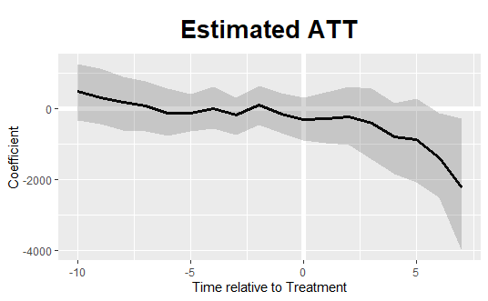

```r
# pdf(file="images/prelim_results/realATT.pdf",
#     width = 3.5, height = 3.1)
plot(out_n2) # ylim = c(-3500, 3500))
```

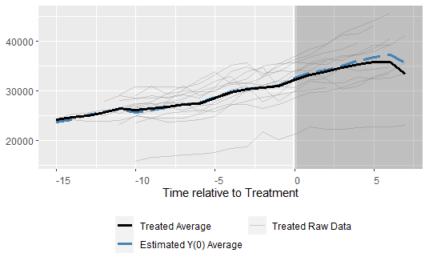

```r
# dev.off()

# plot all data:
plot(out_n2, type = "counterfactual",
     raw = "all", main="") # Why the final dip
```

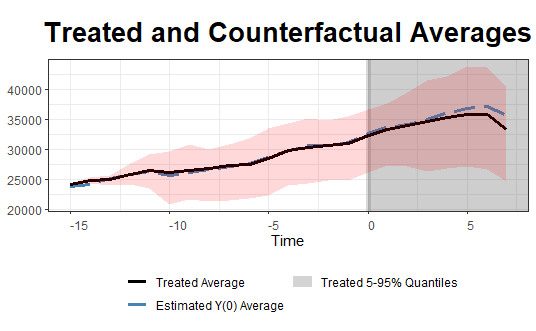

```r
# We can also add two 5 to 95% quantile bands of the treated and control outcomes as references to make sure the estimated counterfactuals are not results of severe extrapolations.

plot(out_n2, type = "counterfactual",
     raw = "band", xlab = "Time",
     # ylim = c(-5,35),
     theme.bw = TRUE)
```

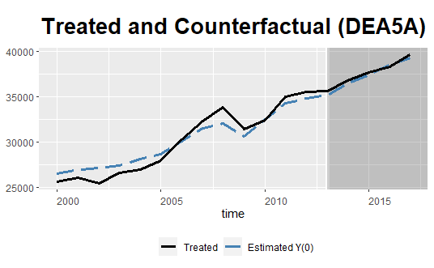

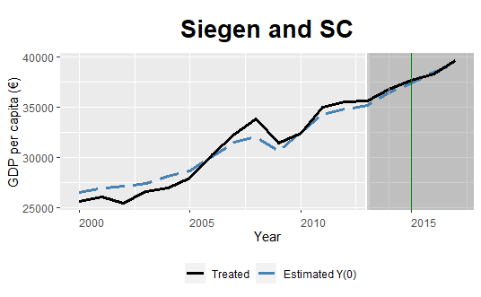

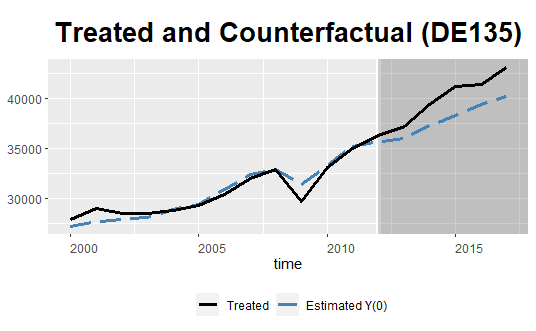

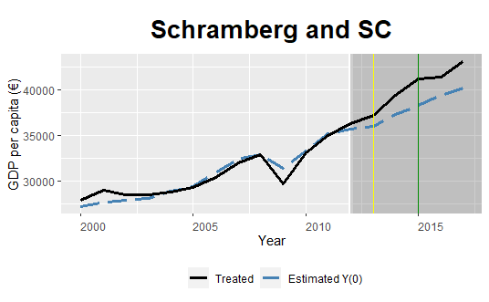

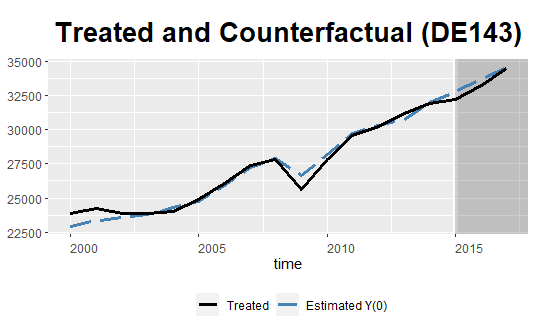

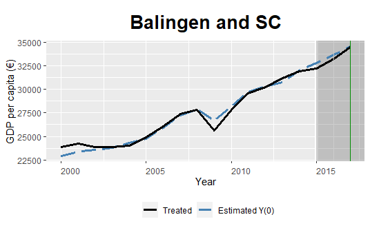

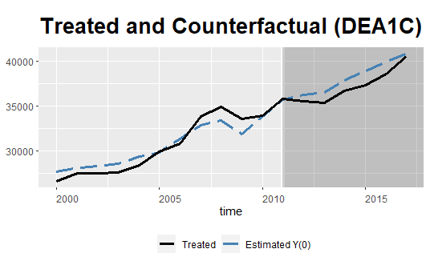

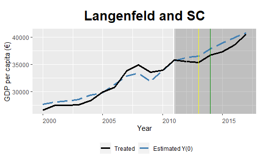

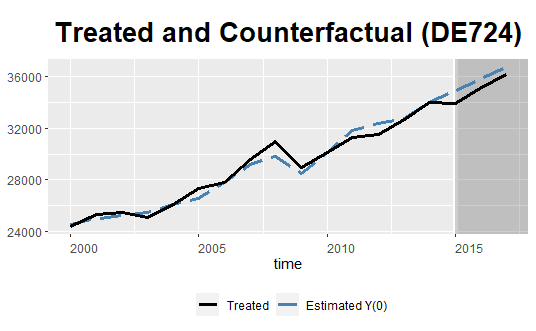

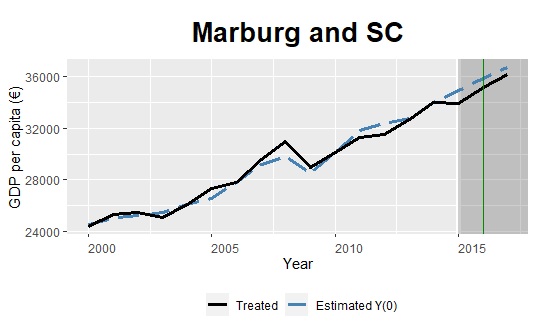

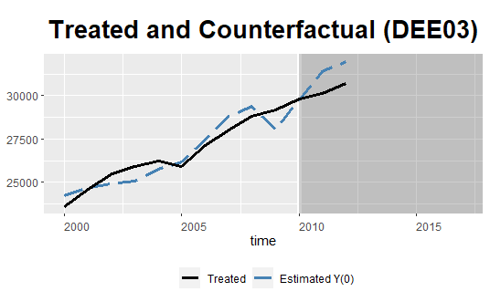

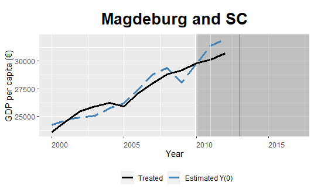

[16 more figures not shown]

```r
for (i in n3_dta[n3_dta$treated_uz == TRUE, ]$geo %>% unique()){
  if (i %in% out_n2$id.tr){
    temp <- plot(out_n2, type = "counterfactual", id = i)
    # pdf(file=paste0("images/prelim_results/ind_real",
    #               "_",  i, ".pdf"),
    # width = 3.5, height = 3.1)
    print(temp +
            geom_vline(xintercept = n3_dta[n3_dta$geo == i,
                                           ]$year_announced[1],
                       color = "grey80") +
            geom_vline(xintercept = n3_dta[n3_dta$geo == i,
                                           ]$year_stage1[1],
                       color = "red1") +
            geom_vline(xintercept = n3_dta[n3_dta$geo == i,
                                           ]$year_stage2[1],
                       color = "yellow1") +
            geom_vline(xintercept = n3_dta[n3_dta$geo == i,
                                           ]$year_stage3[1],
                       color = "green4") +
      labs(
        title = paste0(n3_dta[n3_dta$geo == i,]$LEZ[1],
                       " and SC"),
        y = "GDP per capita (€)",
        x  = "Year"
      )
    )
    # dev.off()
  }
}
```

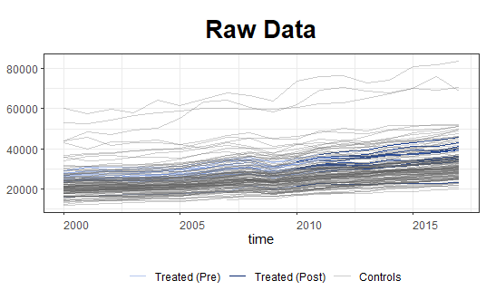

```r
plot(out_n2, type = "raw", theme.bw = TRUE)
```

```
Loadings for the first factor are shown...
```

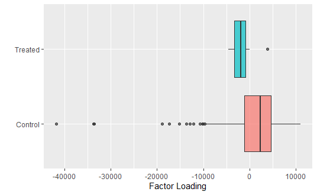

```r
# pdf(file="images/prelim_results/f_loadings.pdf",
#     width = 5, height = 4)
plot(out_n2, type = "loadings", main = "")
```

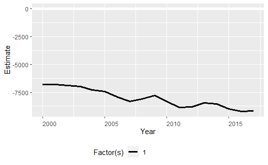

```r
# dev.off()


# pdf(file="images/prelim_results/factors_time.pdf",
#     width = 4, height = 3)
fact_ggplot <- plot(out_n2, type = "factors",
                    main = "",
                    xlab = "Year")
```

```r
# fact_ggplot +
#   labs(title = "",
#        x = "Year")
# dev.off()
```

> Magdeburg suffered from large floods in 2013: Wikipedia + Was one of the most dynamic cities until 2011: https://www.welt.de/wirtschaft/article111642974/Magdeburg-ist-dynamischste-deutsche-Grossstadt.html . Called Mr.Nitche (the economic dep.) at the Rathouse (Frau Koch)

> Heidenheim: “Around 560 jobs in Germany and Austria are to be cut by the end of September 2014.” (after big reduction and not related with environental zones https://www.stuttgarter-nachrichten.de/inhalt.voith-in-heidenheim-hunderte-jobs-in-papiersparte-fallen-weg.29833f08-24a8-4646-9f7c-70527e975c58.html) No major news on the economy for Heidenheim

### 4. (extended)

#### Support for predictors

```
Not a data frame.
```

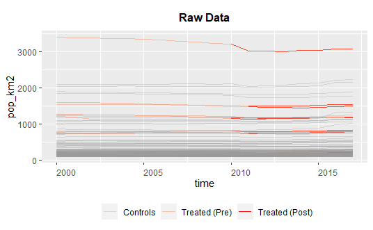

```r
panelView(pop_km2 ~ is_announced, data = n3_dta,
          index = c("geo","time"), type = "outcome")
```

```
Not a data frame.
```

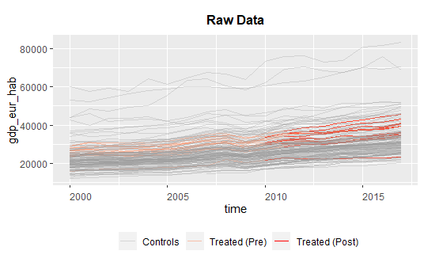

```r
panelView(gdp_eur_hab ~ is_announced, data = n3_dta,
          index = c("geo","time"), type = "outcome")
```

#### Factor analysis

```r
# Know the donor pool of each treated:
weights_result <- out_n2$wgt.implied %>%
  as_tibble(rownames = "NUTS_ID")

# temp <- n2_dta %>%
#   left_join(weights_result, by = c("geo" = "NUTS_ID")) %>%
#   # filter(treated_uz == TRUE)
#   filter(geo == "DE30" | !(is.na(DE30))) %>%
#   filter(time >= 2000 & time <= 2008) %>%
#   group_by(geo == "DE30", time) %>%
#   mutate(DE30 = DE30-mean(DE30)/sd(DE30)) %>%
#   mutate(DE30 = ifelse(geo == "DE30", mean(DE30, na.rm = TRUE), DE30)) %>%
#   dplyr::summarise(mean_unem = weighted.mean(gdp_eur_hab,
#                                              DE30, na.rm = TRUE))
# # %>%
# #   pivot_wider(id_cols = time, names_from = `geo == "DE30"`,
# #               values_from = mean_unem)
#
#   select(geo, time, DE30, unempR_T); temp
# temp
# temp %>%
#   ggplot() +
#   geom_line(aes(x= time, y = mean_unem, color = `geo == "DE30"`))
#
# out_n2$lambda.co # estimated loadings of each factor
out_n2$lambda.tr # estimated loadings of each factor
```

```
               r1
DE113 -3408.82375
DE115 -4556.03036
DE11C -1767.77614
DE135 -3479.80409
DE143  -290.18770
DE724 -1934.27252
DEA15    39.46405
DEA18 -1789.14970
DEA1C -3390.61994
DEA53 -1014.85828
DEA55  3901.97921
DEA5A -3240.50738
DEE03  -878.35831
DEG01 -2946.30402
```

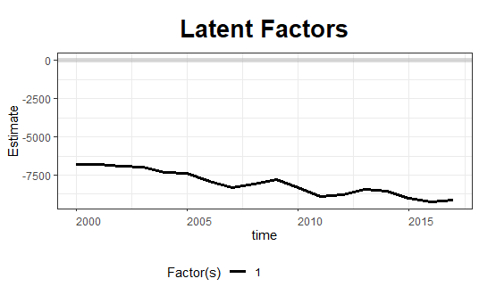

```r
# out_n2$wgt.implied
#
# MASS::ginv(t(as.matrix(out_n2$lambda.tr)))
plot(out_n2, type = "factors", theme.bw = TRUE)
```

```
Loadings for the first factor are shown...
```

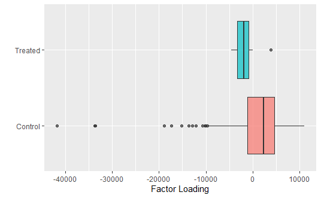

```r
plot(out_n2, type = "loadings")
```

Regarding factors’ evolution:

“Bearing in mind the caveat that estimated factors may not be directly interpretable because they are, at best, linear transformations of the true factors, we find that the estimated factors shown in this figure are meaningful. The first factor captures the sharp increase in turnout in the southern states because of the 1965 Voting Rights Act that removed Jim Crow laws, such as poll taxes or literacy tests, that suppressed turnout.”

Regarding factor loadings:

“Another reassuring finding shown by Figure 3b is that the estimated factor loadings of the nine treated units mostly lie in the convex hull of those of the control units, which indicates that the treated counterfactuals are produced mostly by more reliable interpolations instead of extrapolations.” (paper Gsynth)